# STAT 488 Predictive - Homework 4

Juan M. Cánovas

October 14, 2018

## This data set contains 1000 observations and 25 predictor variables x1-x25 and a response variable y. The response variable is observed for the first 900 observations and missing for the last 100 observations. You job is to build a generalized additive model (GAM) to predict the 100 observations with unobserved reponse variables.

```r
# Requiered libraries
library(mgcv)
library(ggplot2)
library(gamreg)
library(qgam)
```

### 1) Data import

I started by importing the data using `read.csv()`. This function creates a data frame that I called **df**. Next I called `summary(df)`, where we can see that x1 - x25 are quantitative variables (there are no categorical predictors) and the only variable with missing values is the response y.

```r
# Import data
df <- read.csv(file = "C:/Users/Juan Manuel/Documents/STAT 488 Predictive Analytics/Homework/HW 4/PredictiveHW4Dataset.csv")

# Summary
summary(df)
```

```
##        x1                  x2                x3
##  Min.   :0.0003418   Min.   :0.01826   Min.   :-9.9662
##  1st Qu.:0.2581589   1st Qu.:2.43705   1st Qu.:-4.6412
##  Median :0.5101924   Median :4.83464   Median : 0.4002
##  Mean   :0.5072735   Mean   :4.86289   Mean   : 0.2351
##  3rd Qu.:0.7584385   3rd Qu.:7.21874   3rd Qu.: 5.0498
##  Max.   :0.9993030   Max.   :9.96898   Max.   : 9.9752
##
##        x4                  x5                 x6              x7
##  Min.   :0.0008994   Min.   :0.004926   Min.   :4.015   Min.   :0.001171
##  1st Qu.:0.2501172   1st Qu.:1.267886   1st Qu.:5.483   1st Qu.:0.258111
##  Median :0.4776560   Median :2.559438   Median :6.991   Median :0.518469
##  Mean   :0.4959910   Mean   :2.529178   Mean   :6.990   Mean   :0.508545
##  3rd Qu.:0.7404096   3rd Qu.:3.780419   3rd Qu.:8.473   3rd Qu.:0.754655
##  Max.   :0.9992324   Max.   :4.993732   Max.   :9.998   Max.   :0.996565
##
##        x8                 x9                x10
##  Min.   : 0.06404   Min.   :0.004432   Min.   :-9.9404
##  1st Qu.:25.17412   1st Qu.:1.005989   1st Qu.:-6.8455
##  Median :49.50348   Median :1.989346   Median :-3.5599
##  Mean   :49.33710   Mean   :2.004622   Mean   :-3.5713
##  3rd Qu.:73.54565   3rd Qu.:2.998530   3rd Qu.:-0.2997
##  Max.   :99.90955   Max.   :3.984845   Max.   : 2.9547
##
##       x11                x12                x13
##  Min.   :-2.83653   Min.   :-6.40146   Min.   :-9.5153
##  1st Qu.:-0.62417   1st Qu.:-1.36190   1st Qu.:-1.9395
##  Median : 0.02656   Median :-0.02123   Median : 0.1120
##  Mean   : 0.04550   Mean   :-0.01235   Mean   : 0.1383
##  3rd Qu.: 0.70953   3rd Qu.: 1.40472   3rd Qu.: 2.0369
##  Max.   : 3.56078   Max.   : 6.58999   Max.   :10.8543
##
##       x14                 x15                x16
##  Min.   :-12.74265   Min.   :-33.3511   Min.   :-11.9136
##  1st Qu.: -2.55358   1st Qu.: -5.8602   1st Qu.: -2.2774
##  Median :  0.02752   Median : -0.1309   Median :  0.6647
##  Mean   :  0.11723   Mean   : -0.2179   Mean   :  0.5611
##  3rd Qu.:  2.89183   3rd Qu.:  5.5622   3rd Qu.:  3.1230
##  Max.   : 13.42808   Max.   : 27.3892   Max.   : 11.8955
##
```

[output cut: 9 more lines]

```
##  Min.   :-4.6082   Min.   :-4.8332   Min.   :-58.600   Min.   :-54.471
##  1st Qu.:-0.5127   1st Qu.: 0.4815   1st Qu.:-11.959   1st Qu.:-12.353
##  Median : 0.5114   Median : 2.4922   Median :  1.707   Median :  2.054
##  Mean   : 0.4974   Mean   : 2.4643   Mean   :  2.130   Mean   :  2.503
##  3rd Qu.: 1.5091   3rd Qu.: 4.3080   3rd Qu.: 16.296   3rd Qu.: 16.900
##  Max.   : 4.6577   Max.   :10.4535   Max.   : 72.030   Max.   : 69.993
##
##       x25                y                 id
##  Min.   :-28.786   Min.   :-121.86   Min.   :   1.0
##  1st Qu.: -5.912   1st Qu.:  15.45   1st Qu.: 250.8
##  Median :  1.925   Median :  55.71   Median : 500.5
##  Mean   :  1.381   Mean   :  62.21   Mean   : 500.5
##  3rd Qu.:  8.570   3rd Qu.: 106.38   3rd Qu.: 750.2
##  Max.   : 35.121   Max.   : 316.23   Max.   :1000.0
##                    NA's   :100
```

### 2) Initial plots

I continued the analysis by plotting the response y versus each of the predictor variables to try to identify if there is a clear relationship between them. To do this I used `ggplot()` and included the `geom_smooth()` layer.

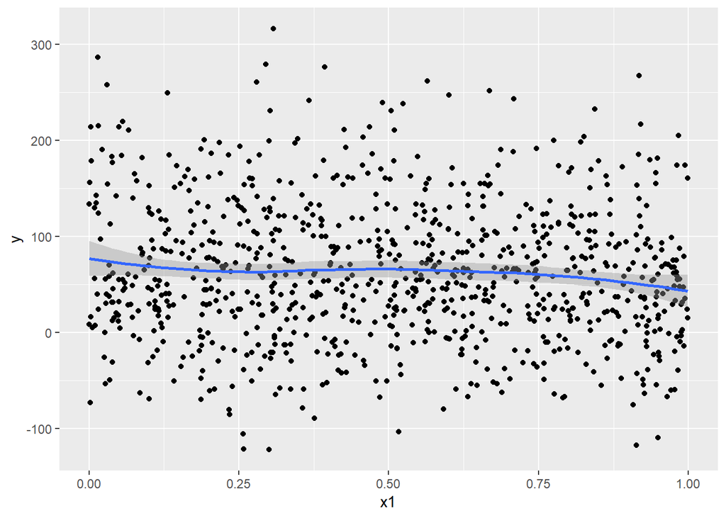

```r
ggplot(data = df, aes(x = x1, y = y)) +
  geom_point() +
  geom_smooth(method = loess)
```

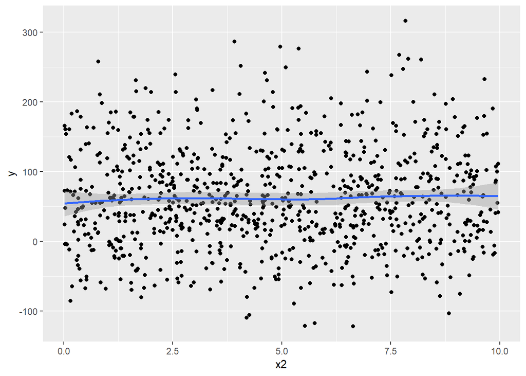

```r
ggplot(data = df, aes(x = x2, y = y)) +
  geom_point() +
  geom_smooth(method = loess)
```

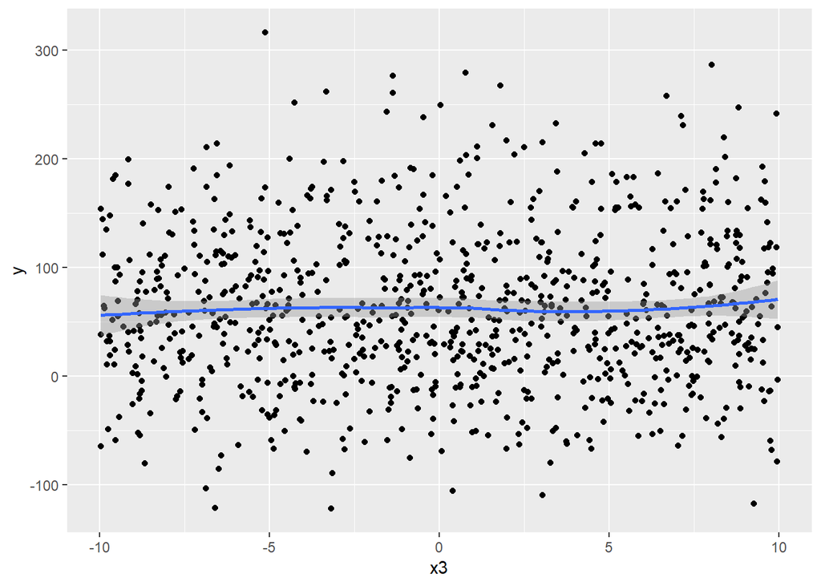

```r
ggplot(data = df, aes(x = x3, y = y)) +
  geom_point() +
  geom_smooth(method = loess)
```

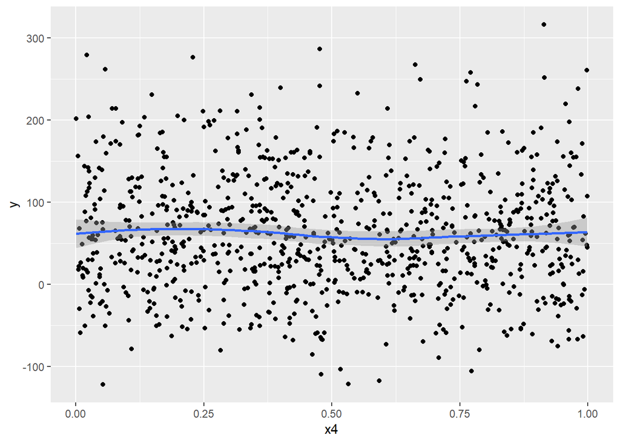

```r
ggplot(data = df, aes(x = x4, y = y)) +
  geom_point() +
  geom_smooth(method = loess)
```

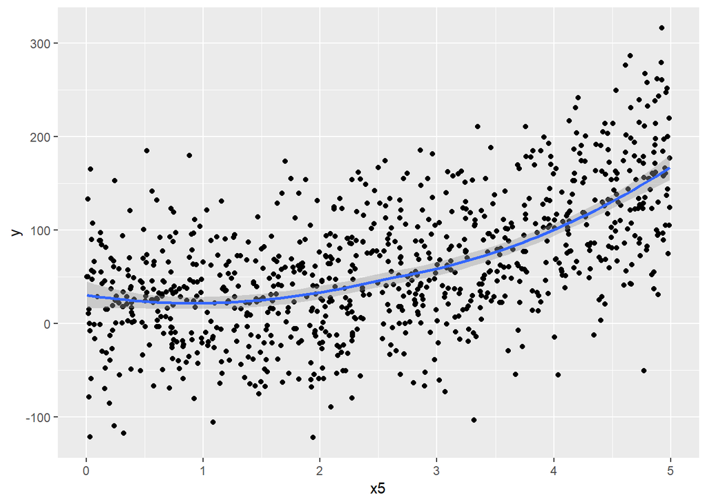

```r
ggplot(data = df, aes(x = x5, y = y)) +
  geom_point() +
  geom_smooth(method = loess)
```

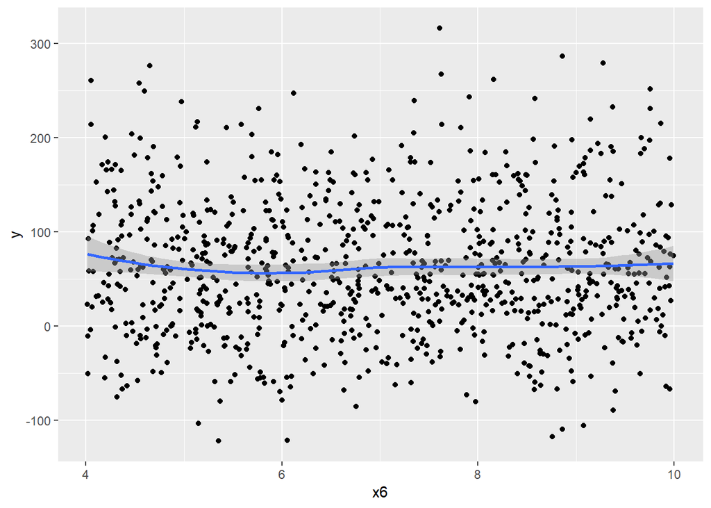

```r
ggplot(data = df, aes(x = x6, y = y)) +
  geom_point() +
  geom_smooth(method = loess)
```

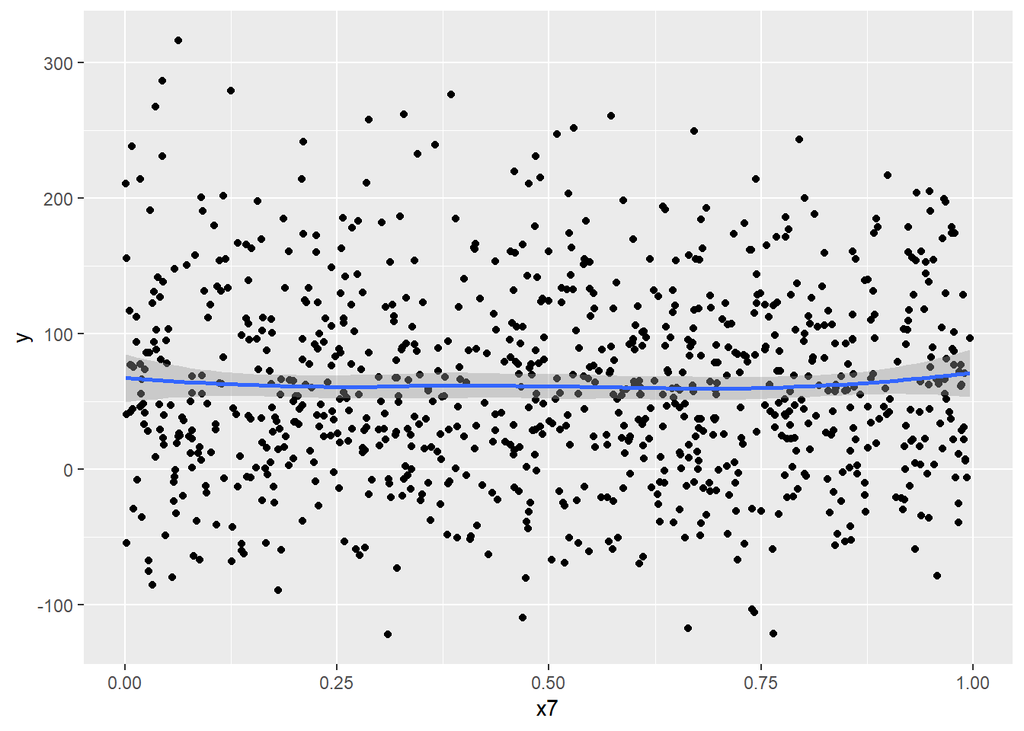

```r
ggplot(data = df, aes(x = x7, y = y)) +
  geom_point() +
  geom_smooth(method = loess)
```

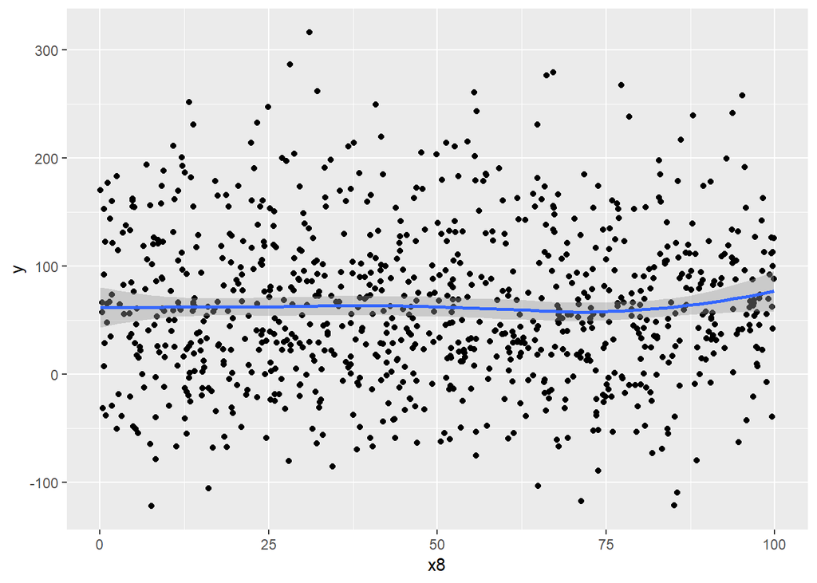

```r
ggplot(data = df, aes(x = x8, y = y)) +
  geom_point() +
  geom_smooth(method = loess)
```

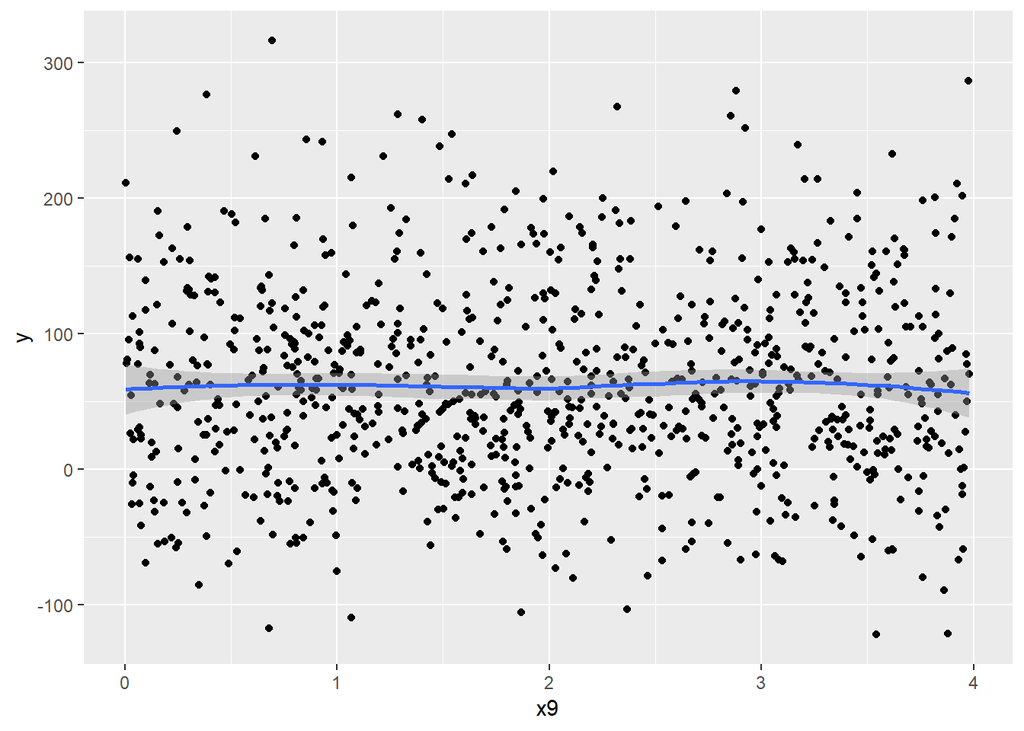

```r
ggplot(data = df, aes(x = x9, y = y)) +
  geom_point() +
  geom_smooth(method = loess)
```

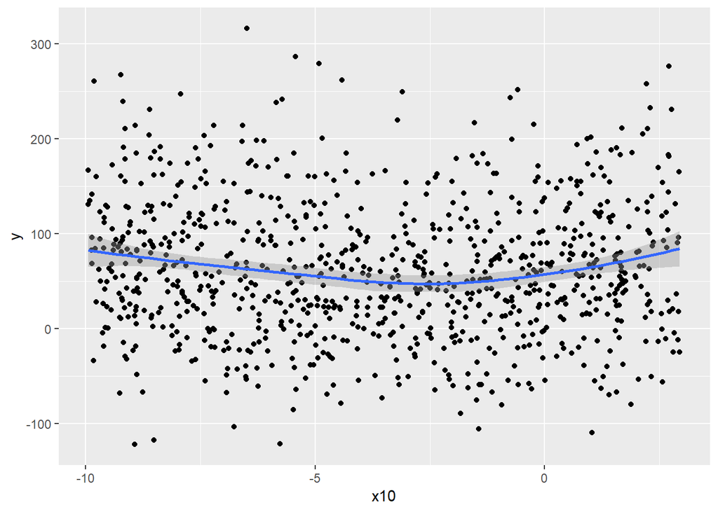

```r
ggplot(data = df, aes(x = x10, y = y)) +
  geom_point() +
  geom_smooth(method = loess)
```

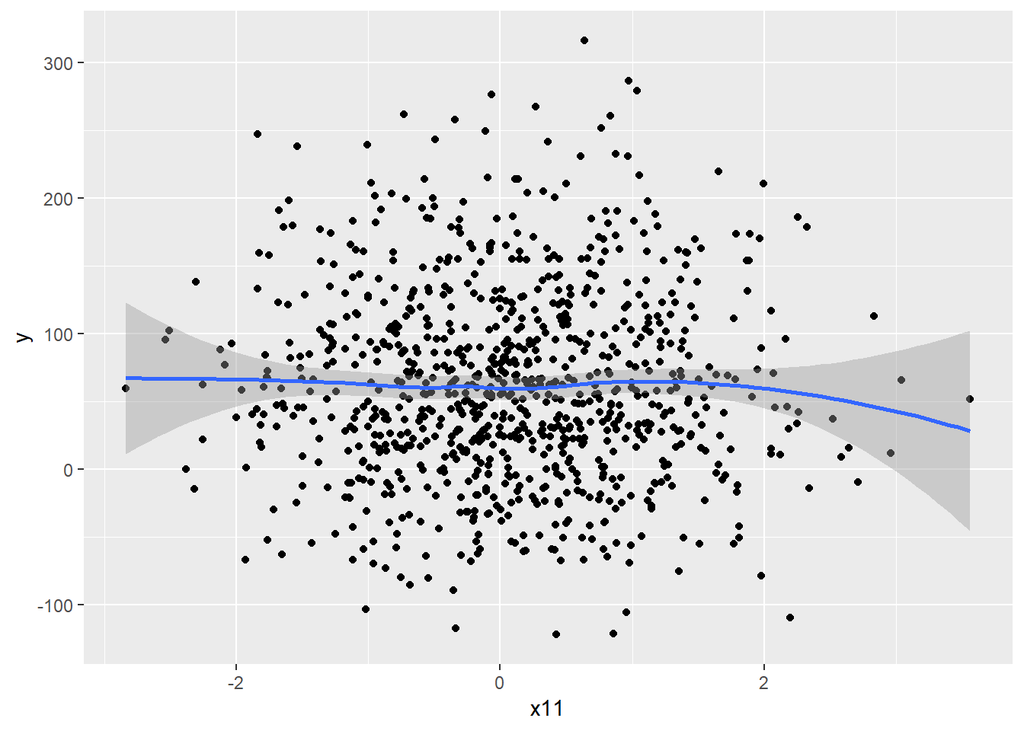

```r
ggplot(data = df, aes(x = x11, y = y)) +
  geom_point() +
  geom_smooth(method = loess)
```

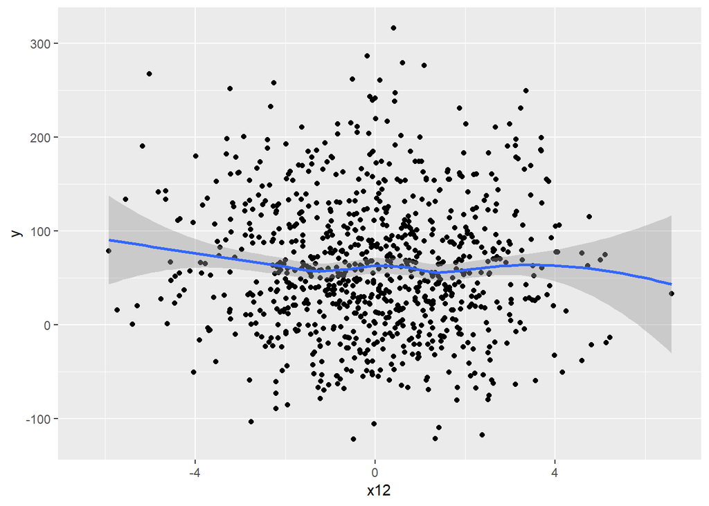

```r
ggplot(data = df, aes(x = x12, y = y)) +
  geom_point() +
  geom_smooth(method = loess)
```

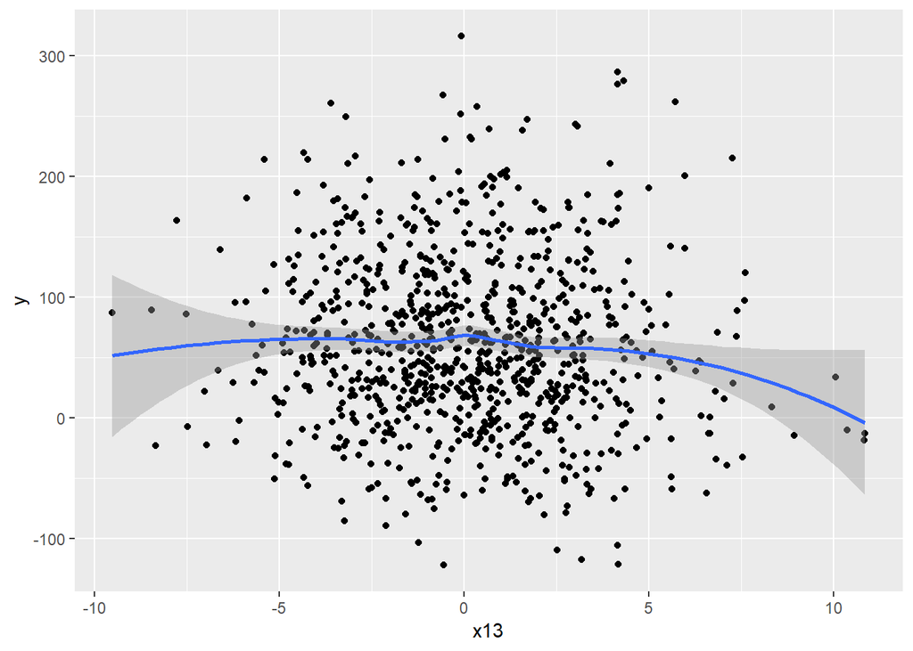

```r
ggplot(data = df, aes(x = x13, y = y)) +
  geom_point() +
  geom_smooth(method = loess)
```

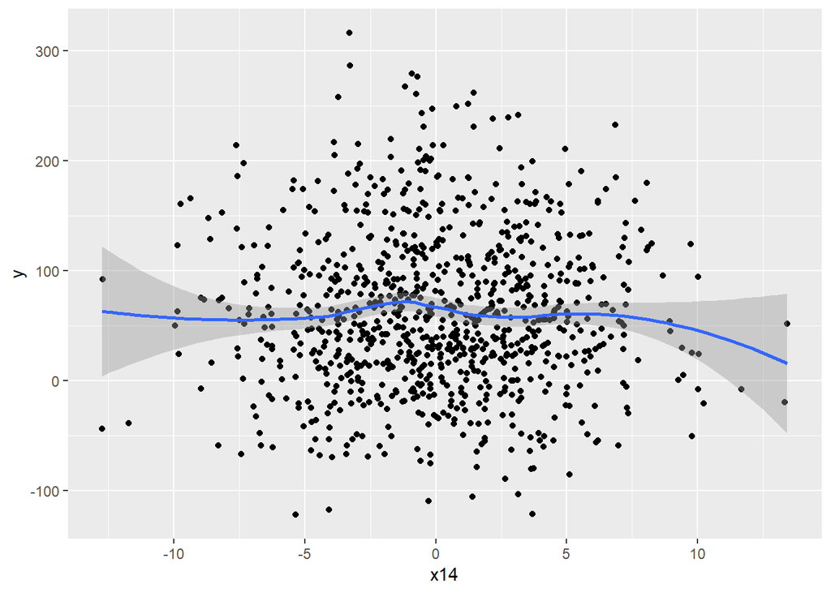

```r
ggplot(data = df, aes(x = x14, y = y)) +
  geom_point() +
  geom_smooth(method = loess)
```

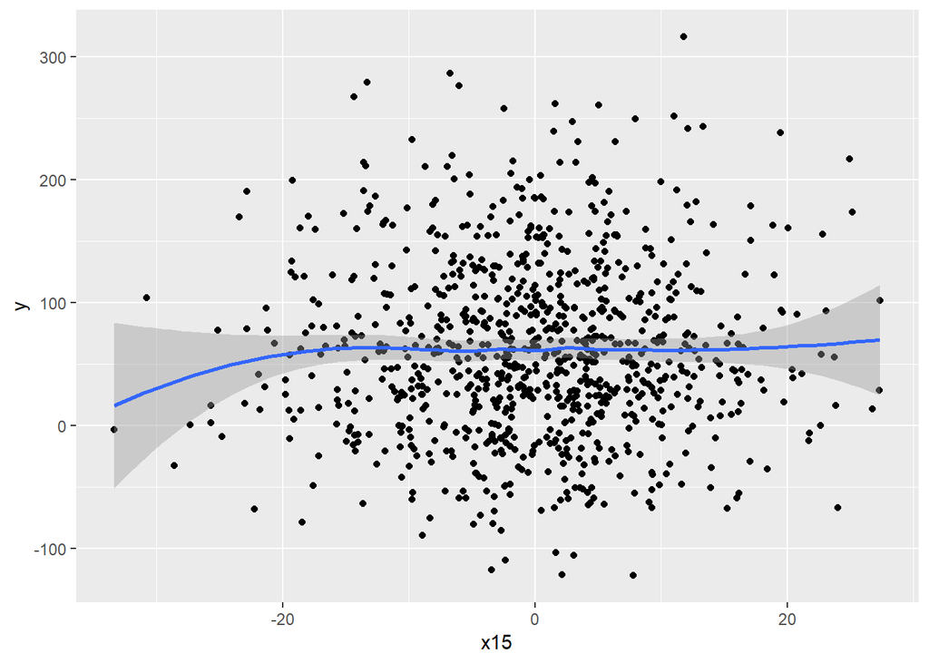

```r
ggplot(data = df, aes(x = x15, y = y)) +
  geom_point() +
  geom_smooth(method = loess)
```

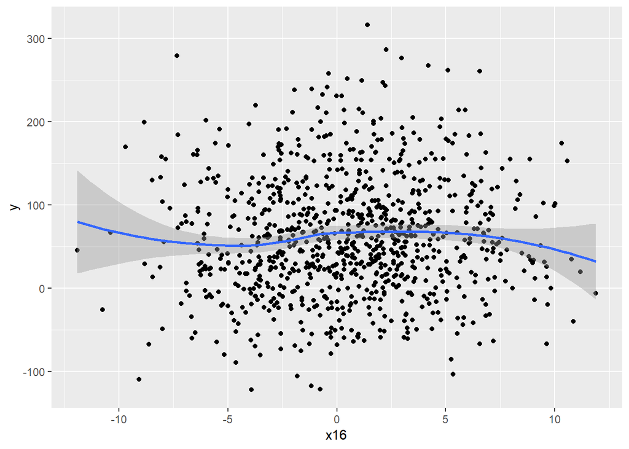

```r
ggplot(data = df, aes(x = x16, y = y)) +
  geom_point() +
  geom_smooth(method = loess)
```

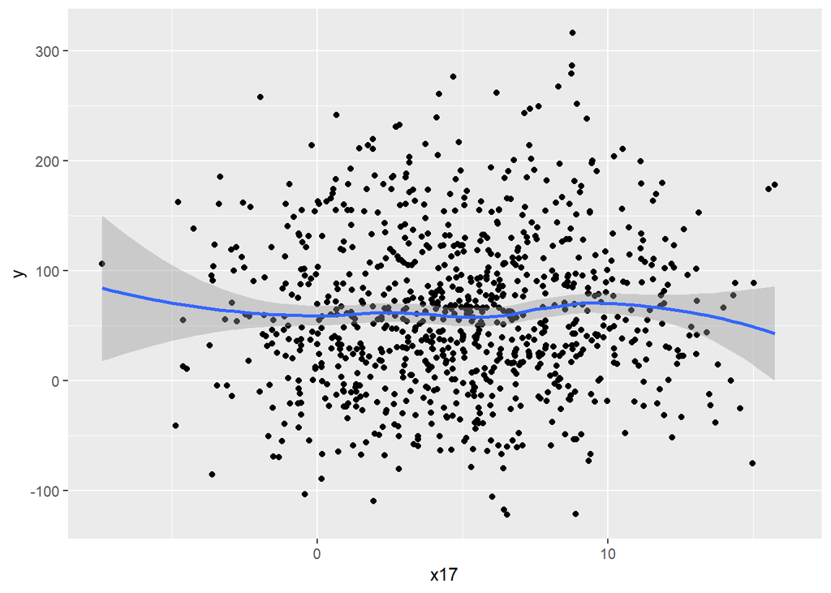

```r
ggplot(data = df, aes(x = x17, y = y)) +
  geom_point() +
  geom_smooth(method = loess)
```

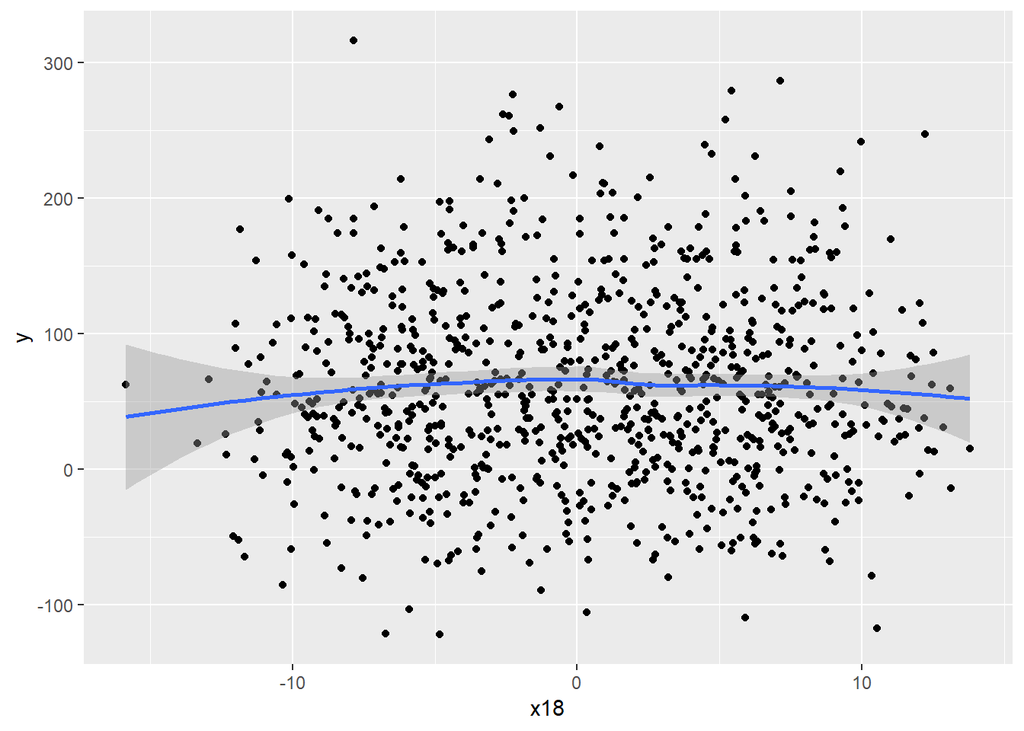

```r
ggplot(data = df, aes(x = x18, y = y)) +
  geom_point() +
  geom_smooth(method = loess)
```

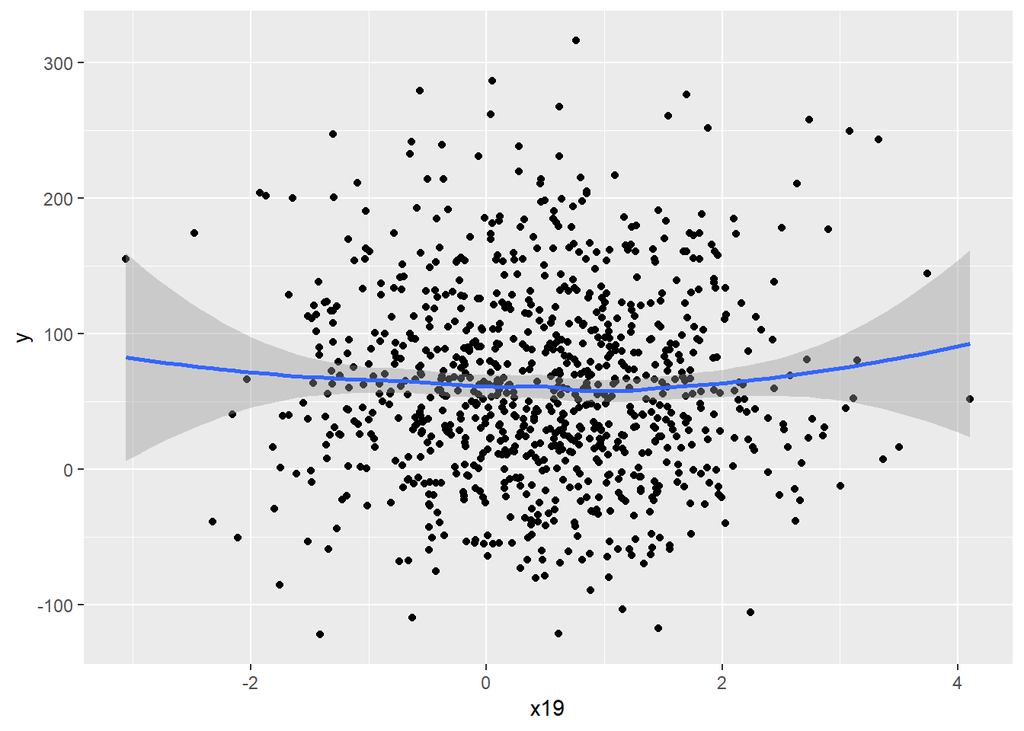

```r
ggplot(data = df, aes(x = x19, y = y)) +
  geom_point() +
  geom_smooth(method = loess)
```

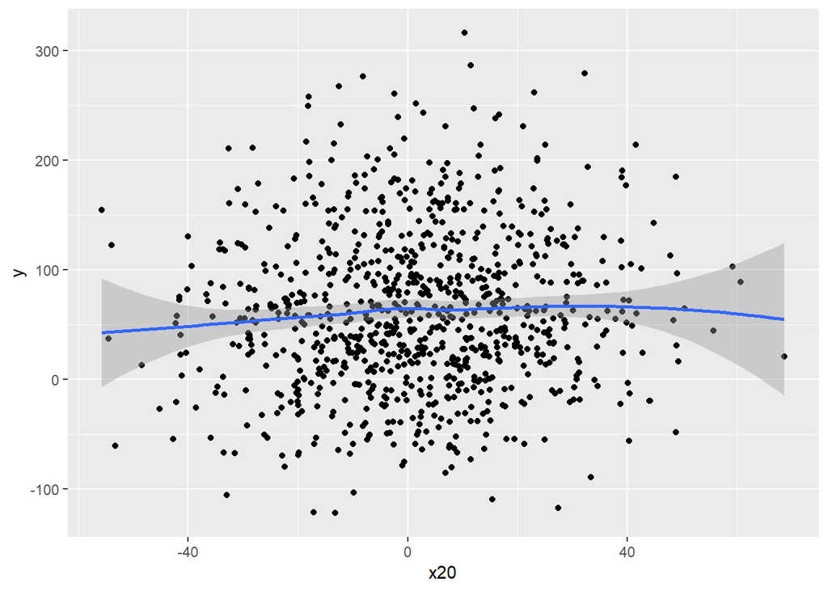

```r
ggplot(data = df, aes(x = x20, y = y)) +
  geom_point() +
  geom_smooth(method = loess)
```

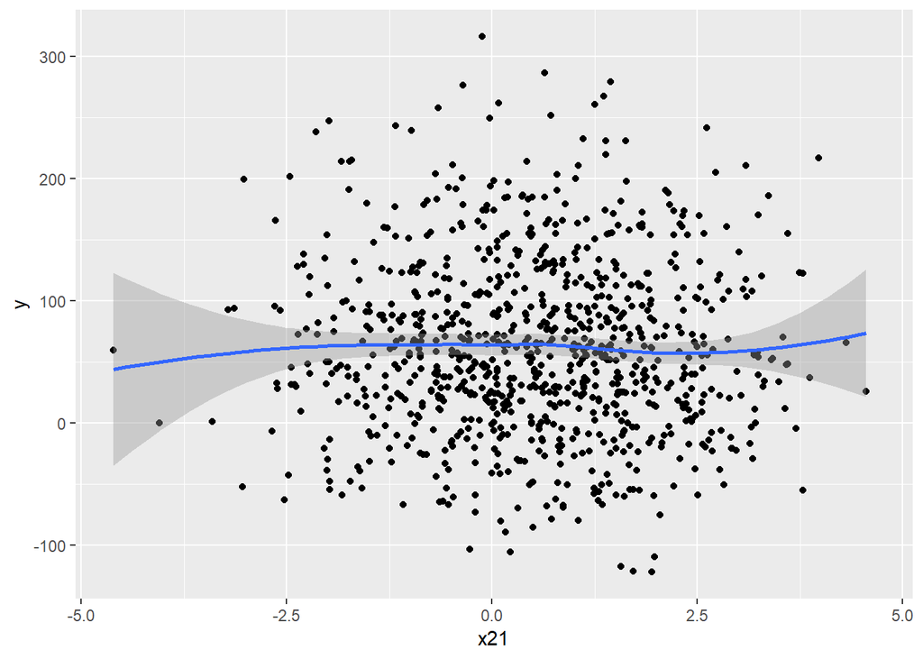

```r
ggplot(data = df, aes(x = x21, y = y)) +
  geom_point() +
  geom_smooth(method = loess)
```

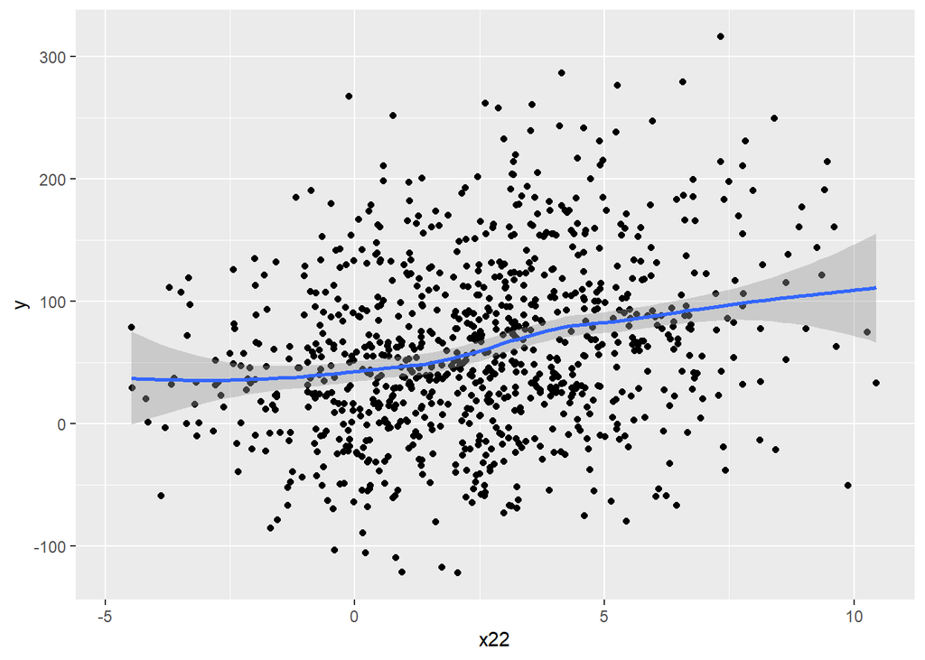

```r
ggplot(data = df, aes(x = x22, y = y)) +
  geom_point() +
  geom_smooth(method = loess)
```

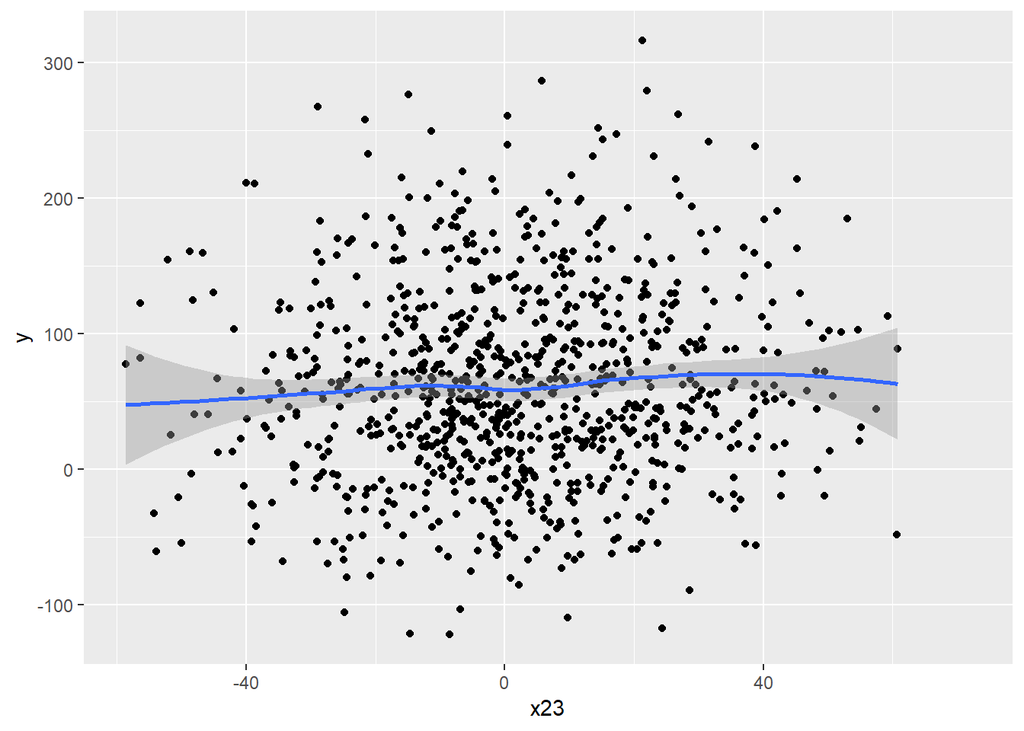

```r
ggplot(data = df, aes(x = x23, y = y)) +
  geom_point() +
  geom_smooth(method = loess)
```

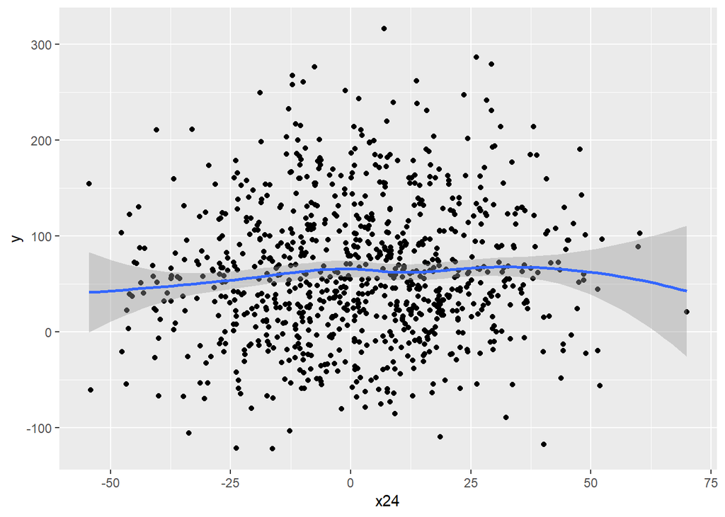

```r
ggplot(data = df, aes(x = x24, y = y)) +
  geom_point() +
  geom_smooth(method = loess)
```

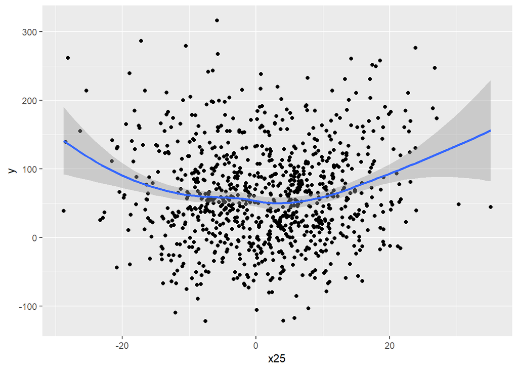

```r
ggplot(data = df, aes(x = x25, y = y)) +
  geom_point() +
  geom_smooth(method = loess)
```

### 3) Train and test sets

In the next sections I will fit several models with a train set, make predictions with a test set, calculate the prediction’s MSE, and compare. In order to do that, in this section I created the train and test sets.

I used 70% of the labeled observations for the train set and the remaining 30% for the test set.

```r
# Consider only the rows without NA
df2 <- df[1:900, ]
size <- round(900 * 0.7)

# Seed
set.seed(1234)

# Train and test
idx <- sample(x = nrow(df2), size = size, replace = FALSE)
train <- df2[idx, ]
test <- df2[-idx, ]
```

### 3) Variable selection

I continued the model fitting process by doing variable selection using the function `cv.gam()` from the package **gamreg**. This function performs robust cross validation and returns three objects: lambda, fit, and Rocv. From the function help file, the object Rocv is the one that contains the result of best model by Robust Cross-Validation.

```r
# Cross validation
cv_g1 <- cv.gam(as.matrix(df2[ , 1:25]), as.matrix(df2[ , 26]))
```

```
##
## init.mode is sLTS
## The number of lambda is 50
## gamma is 0.1 gamma0 is 0.5
```

```r
cv_g1$Rocv    # This object has the cross-validation results
```

```
## $beta0
## [1] 7.311395
##
## $beta
##               [,1]
##  [1,] -12.12418607
##  [2,]   0.00000000
##  [3,]   0.10561612
##  [4,]  -2.56142476
##  [5,]  24.56563624
##  [6,]   0.00000000
##  [7,]   0.00000000
##  [8,]   0.00000000
##  [9,]   0.00000000
## [10,]   0.00000000
```

[output cut: 18 more lines]

### 4) Model fitting

In the model fitting step I am using the function `gam()` from the **mgcv** package.

This function can estimate the smoothing parameter using different methods. Some resources on the Internet, as well as function’s author page, advise to use REML so I set `method = "REML"`.

For fitting the model I also used `select = TRUE`. From the function help file: *“if this is TRUE then gam can add an extra penalty to each term so that it can be penalized to zero. This means that the smoothing parameter estimation that is part of fitting can completely remove terms from the model.”*

```r
# Model g1 fit with training data
set.seed(1234)
g1 <- gam(y ~ s(x1) + s(x3) + s(x4) + s(x5) +
             s(x12) + s(x13) + s(x16) + s(x23),
           data = train, method = "REML", select = TRUE)

# Predictions model g1
g1_pred <- predict.gam(g1, newdata = test)

# MSEP model g1
MSEP1 <- mean((test[ , "y"] - g1_pred)^2)
MSEP1
```

```
## [1] 3535.515
```

```r
# Model g2 fit with training data
set.seed(1234)
g2 <- gam(y ~ s(x1) + s(x3) + s(x4) + s(x5) +
             s(x12) + s(x13) + s(x16) + s(x22) + s(x23) + s(x25),
           data = train, method = "REML", select = TRUE)

# Predictions model g2
g2_pred <- predict.gam(g2, newdata = test)

# MSEP model g2
MSEP2 <- mean((test[ , "y"] - g2_pred)^2)
MSEP2
```

```
## [1] 3552.34
```

```r
# Model g3 fit with training data
set.seed(1234)
g3 <- gam(y ~ s(x1) + s(x3) + s(x4) + s(x5) + s(x10) +
             s(x12) + s(x13) + s(x16) + s(x22) + s(x23) + s(x25),
           data = train, method = "REML", select = TRUE)

# Predictions model g3
g3_pred <- predict.gam(g3, newdata = test)

# MSEP model g3
MSEP3 <- mean((test[ , "y"] - g3_pred)^2)
MSEP3
```

```
## [1] 3379.061
```

### 5) Model comparison

To compare the models I used the prediction MSE, AIC and BIC.

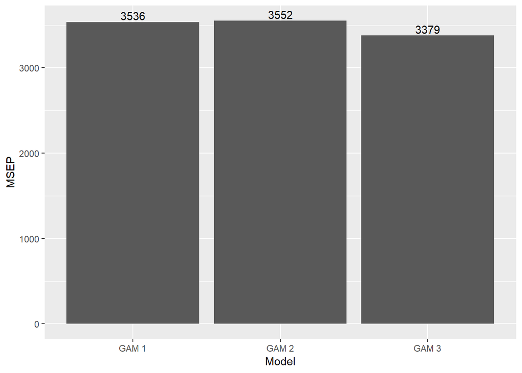

```r
# Data frame
gnames <- c("GAM 1", "GAM 2", "GAM 3")
gMSEP <- c(MSEP1, MSEP2, MSEP3)

# Bar plot
ggplot(data = data.frame(gnames, gMSEP), aes(gnames, gMSEP)) +
  geom_text(aes(label = round(gMSEP)), position = position_dodge(width = 0.9), vjust = -0.25) +
  geom_bar(position = "dodge", stat = "identity") +
  xlab("Model") +
  ylab("MSEP")
```

```r
# AIC
AIC(g1, g2, g3)
```

```
##          df      AIC
## g1 13.02237 6880.359
## g2 16.43998 6847.962
## g3 20.72815 6820.788
```

```r
# BIC
BIC(g1, g2, g3)
```

```
##          df      BIC
## g1 13.02237 6938.253
## g2 16.43998 6921.049
## g3 20.72815 6912.940
```

The comparison of MSEP, AIC, and BIC led me to choose model **g3**.

### 6) Model checking

#### 6.1) Basis dimension

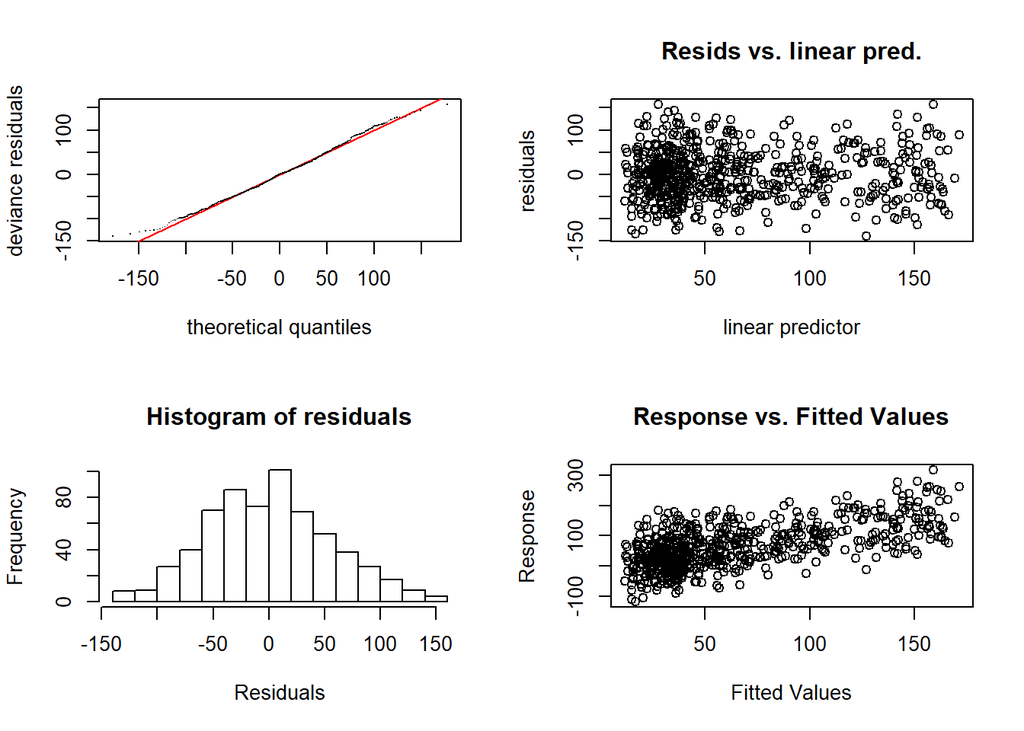

```
##
## Method: REML   Optimizer: outer newton
## full convergence after 12 iterations.
## Gradient range [-0.0008104405,0.0004338619]
## (score 3438.999 & scale 3154.633).
## Hessian positive definite, eigenvalue range [7.510189e-05,314.5106].
## Model rank =  73 / 73
##
## Basis dimension (k) checking results. Low p-value (k-index<1) may
## indicate that k is too low, especially if edf is close to k'.
##
##             k'     edf k-index p-value
## s(x1)  9.00000 0.54643    1.01    0.58
## s(x3)  9.00000 1.00043    0.93    0.03 *
## s(x4)  9.00000 0.38832    0.96    0.22
## s(x5)  9.00000 3.58898    1.00    0.49
## s(x12) 9.00000 0.46335    0.98    0.28
## s(x13) 9.00000 0.73958    1.02    0.68
## s(x16) 9.00000 1.42677    0.99    0.40
## s(x23) 9.00000 0.00269    1.07    0.97
## ---
## Signif. codes:  0 '***' 0.001 '**' 0.01 '*' 0.05 '.' 0.1 ' ' 1
```

```r
# Check model 1
gam.check(g1)
```

The first part of the output presents four plots that looks good. None of them is showing a pattern to worry about.

#### 6.2) Concurvity

Dr. Matthews: I came across the concept of concurvity and try to use it to improve the model. However, the changes that I did after finding concurvity did not improve the model.  
It seems that concurvity can be a problem when the function is trying to estimate the smoothing parameter. The only extra information that I found about concurvity is in the book *“Generalized Additive Models: an introduction with R”* by Simon Wood. In page 176 it says:

> This sort of problem is particularly common in the presence of concurvity, for example when a model includes terms such as $f_{1}(x_{i}) + f_{2}(z_{i})$, but $z$ is itself a smooth function of $x$: in this circumstance the smooth functions, $f_{1}$ and $f_{2}$, are confounded, and there may be very little information in $\nu_{\frac{u}{g}}$ from which to estimate their smoothing parameters separately: neglected dependencies in the performance iteration approach then become critical. Concurvity problems like this are very common in models which include a smooth of spatial location, and a number of covariates which themselves vary fairly smoothly over space.

To check for concurvity, I used `concurvity()` function from **mgcv** package. First, I set the argument `full = TRUE` and this considers concurvity of each term with the whole of the rest of the model.

```r
# Concurvity model g3: full = TRUE
concurvity(g3, full = TRUE)
```

```
##                  para     s(x1)     s(x3)     s(x4)     s(x5)    s(x10)
## worst    3.793005e-23 0.2021970 0.2198401 0.2037815 0.7107613 0.2237647
## observed 3.793005e-23 0.1563738 0.1505923 0.1541325 0.6101097 0.1444437
## estimate 3.793005e-23 0.1574016 0.1249076 0.1528843 0.6315202 0.1653357
##             s(x12)     s(x13)    s(x16)    s(x22)    s(x23)    s(x25)
## worst    0.8377427 0.25775803 0.2153252 0.8830930 0.2186809 0.2017489
## observed 0.8324538 0.08892743 0.1146805 0.8789397 0.1445523 0.1405627
## estimate 0.6931655 0.10725153 0.1330316 0.7326667 0.1434403 0.1380775
```

I focused on the case “worst” and only considered those cases where concurvity is greater than 0.8, which are the smoothers s(x12) and s(x22). Next, I set the argument `full = FALSE` where pairwise concurvity measures between each smooth term (as well as the parametric component) are considered.

```r
# Concurvity model g3: full = FALSE
g3_concurvity <- concurvity(g3, full = FALSE)

g3_concurvity[[1]][ , c(7, 10)]
```

```
##              s(x12)       s(x22)
## para   1.026831e-26 2.941095e-23
## s(x1)  5.018234e-02 4.896626e-02
## s(x3)  4.548191e-02 2.929528e-02
## s(x4)  4.568168e-02 3.676689e-02
## s(x5)  4.216976e-02 3.098060e-01
## s(x10) 6.260630e-02 4.232561e-02
## s(x12) 1.000000e+00 6.204385e-01
## s(x13) 5.178870e-02 4.407153e-02
## s(x16) 5.115047e-02 2.646436e-02
## s(x22) 6.204385e-01 1.000000e+00
## s(x23) 4.681701e-02 4.018267e-02
## s(x25) 3.025618e-02 3.389602e-02
```

`concurvity` returns a list whose first component has the values for case “worst”. From there, I am selecting only columns 7 and 10 which corresponds to s(x12) and s(x22), respectively. Here we observe that the value of concurvity between this two smooths is 0.62. The concurvity values with other smooths is really small.

### 7) Interaction

I fit a new model, called **g4**, where I am including a smooth for both x12 and x22 namely, s(x12, x22). But as I mentioned before, this does not show an improvement over model **g3**.

```r
# Model g4 fit with training data
set.seed(1234)
g4 <- gam(y ~ s(x1) + s(x3) + s(x4) + s(x5) + s(x10) +
            s(x12) + s(x13) + s(x16) + s(x22) + s(x23) + s(x25) + s(x12, x22),
          data = train, method = "REML", select = TRUE)
# Predictions model g4
g4_pred <- predict.gam(g4, newdata = test)
# MSEP model g4
MSEP4 <- mean((test[ , "y"] - g4_pred)^2)
MSEP4
```

```
## [1] 3379.042
```

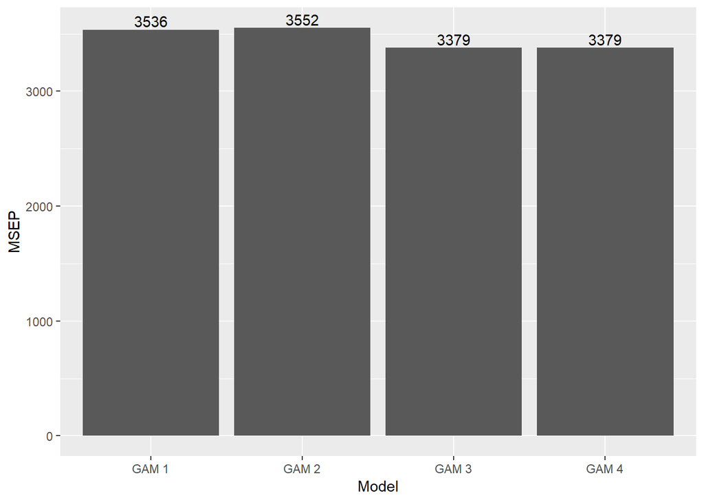

```r
# Data frame
gnames <- c(gnames, "GAM 4")
gMSEP <- c(gMSEP, MSEP4)

# Bar plot
ggplot(data = data.frame(gnames, gMSEP), aes(gnames, gMSEP)) +
  geom_text(aes(label = round(gMSEP)), position = position_dodge(width = 0.9), vjust = -0.25) +
  geom_bar(position = "dodge", stat = "identity") +
  xlab("Model") +
  ylab("MSEP")
```

```r
# AIC
AIC(g1, g2, g3, g4)
```

```
##          df      AIC
## g1 13.02237 6880.359
## g2 16.43998 6847.962
## g3 20.72815 6820.788
## g4 20.71824 6820.776
```

```r
# BIC
BIC(g1, g2, g3, g4)
```

```
##          df      BIC
## g1 13.02237 6938.253
## g2 16.43998 6921.049
## g3 20.72815 6912.940
## g4 20.71824 6912.884
```

### 8) Quantile GAM

Another approach to this problem is to try to fit a quantile GAM instead. To do so, I used function `qgam()` in package **qgam**. This function is similar to `gam()` in **mgcv** but now we have to specify the quantile we are interested in through the argument `qu`. In this case, I used `qu = 0.5`

```r
set.seed(1234)
q1 <- qgam(y ~ s(x1) + s(x3) + s(x4) + s(x5) + s(x10) +
            s(x12) + s(x13) + s(x16) + s(x22) + s(x23) + s(x25),
           data = train, qu = 0.5, argGam = list(method = "REML", select = TRUE))
```

```
## Estimating learning rate. Each dot corresponds to a loss evaluation.
## qu = 0.5.............done
```

```r
q1_pred <- predict.gam(q1, newdata = test)
MSEP5 <- mean((test[ , "y"] - q1_pred)^2)
MSEP5
```

```
## [1] 3359.292
```

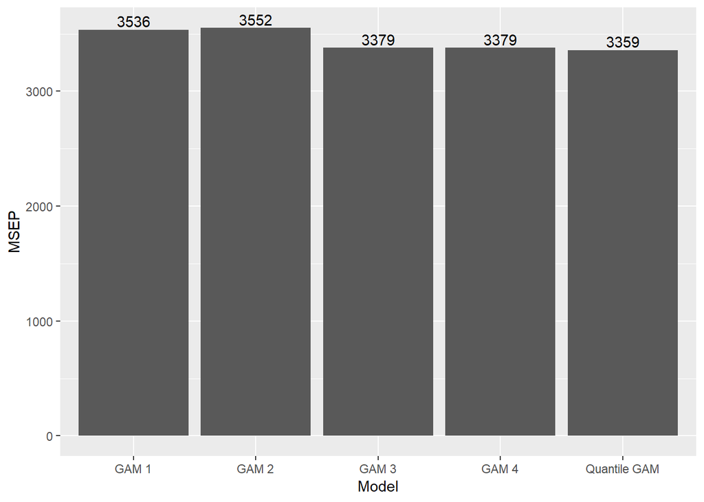

```r
# Data set
gnames <- c(gnames, "Quantile GAM")
gMSEP <- c(gMSEP, MSEP5)

# Bar plot
ggplot(data = data.frame(gnames, gMSEP), aes(gnames, gMSEP)) +
  geom_text(aes(label = round(gMSEP)), position = position_dodge(width = 0.9), vjust = -0.25) +
  geom_bar(position = "dodge", stat = "identity") +
  xlab("Model") +
  ylab("MSEP")
```

```r
# AIC
AIC(g1, g2, g3, g4, q1)
```

```
##          df      AIC
## g1 13.02237 6880.359
## g2 16.43998 6847.962
## g3 20.72815 6820.788
## g4 20.71824 6820.776
## q1 22.13493 6879.060
```

```r
# BIC
BIC(g1, g2, g3, g4, q1)
```

```
##          df      BIC
## g1 13.02237 6938.253
## g2 16.43998 6921.049
## g3 20.72815 6912.940
## g4 20.71824 6912.884
## q1 22.13493 6977.465
```

### 9) Different seeds

Even though MSEP is better for the quantile GAM **q1**, AIC and BIC are better for model **g3**. For this reason I fitted the models **g3** and **q1** several times using different seeds to split the data set into train and test. With this I am trying to indentify if one model is better than the other, of if the differences are only due to the particular data used to train and test.

```r
# Different seeds
df2 <- df[1:900, ]
size <- round(900 * 0.7)
seeds <- c(1, 27, 337, 1001, 1234)

MSEPg3 <- rep(NA, 5)
AICg3 <- rep(NA, 5)
BICg3 <- rep(NA, 5)

MSEPq1 <- rep(NA, 5)
AICq1 <- rep(NA, 5)
BICq1 <- rep(NA, 5)


for (i in 1:5){
  # Seed
  set.seed(seeds[i])

  # Train and test
  idx <- sample(x = nrow(df2), size = size, replace = FALSE)
  train <- df2[idx, ]
  test <- df2[-idx, ]

  # Model g3 fit with training data
  g3 <- gam(y ~ s(x1) + s(x3) + s(x4) + s(x5) + s(x10) +
              s(x12) + s(x13) + s(x16) + s(x22) + s(x23) + s(x25),
            data = train, method = "REML", select = TRUE)

  # Model q1 fit with training data
  q1 <- qgam(y ~ s(x1) + s(x3) + s(x4) + s(x5) + s(x10) +
               s(x12) + s(x13) + s(x16) + s(x22) + s(x23) + s(x25),
             data = train, qu = 0.5, argGam = list(method = "REML", select = TRUE))

  # Predictions model g3
  g3_pred <- predict.gam(g3, newdata = test)

  # Predictions model q1
  q1_pred <- predict.gam(q1, newdata = test)

  # MSEP model g3
  MSEPg3[i] <- mean((test[ , "y"] - g3_pred)^2)

  # MSEP model q1
  MSEPq1[i] <- mean((test[ , "y"] - q1_pred)^2)

  # AIC and BIC
  AICg3[i] <- AIC(g3)
  BICg3[i] <- BIC(g3)
  AICq1[i] <- AIC(q1)
  BICq1[i] <- BIC(q1)
}
```

```
## Estimating learning rate. Each dot corresponds to a loss evaluation.
## qu = 0.5.............done
## Estimating learning rate. Each dot corresponds to a loss evaluation.
## qu = 0.5............done
## Estimating learning rate. Each dot corresponds to a loss evaluation.
## qu = 0.5.............done
## Estimating learning rate. Each dot corresponds to a loss evaluation.
## qu = 0.5...............done
## Estimating learning rate. Each dot corresponds to a loss evaluation.
## qu = 0.5.............done
```

```r
mean(MSEPg3)
```

```
## [1] 3185.122
```

```r
mean(MSEPq1)
```

```
## [1] 3211.298
```

```r
mean(AICg3)
```

```
## [1] 6839.424
```

```r
mean(AICq1)
```

```
## [1] 6890.016
```

```r
mean(BICg3)
```

```
## [1] 6923.98
```

```r
mean(BICq1)
```

```
## [1] 6979.091
```

Using five different seeds and computing the average MSEP for each model, we see that model **g3** has lower MSEP, AIC and BIC.

### 10) Predictions

I select model **g3** and with that I will make my predictions for the 100 observations with missing value of y. Because I used the names train, test, g3, etc. inside the for loop in section 9), now I will fit model g3 again for reproducibility.

```r
# Consider only the rows without NA
df2 <- df[1:900, ]
size <- round(900 * 0.7)

# Seed
set.seed(1234)

# Train and test
idx <- sample(x = nrow(df2), size = size, replace = FALSE)
train <- df2[idx, ]
test <- df2[-idx, ]

# Fit model g3 again
# Model g3 fit with training data
set.seed(1234)
g3 <- gam(y ~ s(x1) + s(x3) + s(x4) + s(x5) + s(x10) +
             s(x12) + s(x13) + s(x16) + s(x22) + s(x23) + s(x25),
           data = train, method = "REML", select = TRUE)
```

```r
# Predictions
prediction_data <- df[901:1000, ]

# This is the predicted y values
y <- predict(g3, newdata = prediction_data)

# Submission file
id <- prediction_data$id
gam_submission <- data.frame(y, id)

write.csv(gam_submission, file = "C:/Users/Juan Manuel/Documents/STAT 488 Predictive Analytics/Homework/HW 4/gam_submission.csv", row.names = FALSE)
```